# 17.2: Robust regression

## Introduction

This is code for Section 17.2 of Kruschke using a Student t noise distribution. Other than that change, this document is identical to the one from section 7.1.

Make sure that the two files “WtHtData30.csv” and “WtHtData300.csv” are in your project directory.

## Preliminaries

Load necessary packages:

```r
library(tidyverse)
library(rstan)
library(shinystan)
library(bayesplot)
```

Set Stan to save compiled code.

```r
rstan_options(auto_write = TRUE)
```

Set Stan to use parallel processing where possible.

```r
options(mc.cores = parallel::detectCores())
```

## Data

```r
WtHtData30 <- read_csv("WtHtData30.csv")
WtHtData30
```

| male | height | weight |
| --- | --- | --- |
| 0 | 64.0 | 136.4 |
| 0 | 62.3 | 215.1 |
| 1 | 67.9 | 173.6 |
| 0 | 64.2 | 117.3 |
| 0 | 64.8 | 123.3 |
| 0 | 57.5 | 96.5 |
| 0 | 65.6 | 178.3 |
| 1 | 70.2 | 191.1 |
| 0 | 63.9 | 158.0 |
| 1 | 71.1 | 193.9 |

[output cut: 20 more lines]

```r
WtHtData300 <- read_csv("WtHtData300.csv")
WtHtData300
```

| male | height | weight |
| --- | --- | --- |
| 0 | 64.0 | 136.4 |
| 0 | 62.3 | 215.1 |
| 1 | 67.9 | 173.6 |
| 0 | 64.2 | 117.3 |
| 0 | 64.8 | 123.3 |
| 0 | 57.5 | 96.5 |
| 0 | 65.6 | 178.3 |
| 1 | 70.2 | 191.1 |
| 0 | 63.9 | 158.0 |
| 1 | 71.1 | 193.9 |

[output cut: 290 more lines]

We’ll also be interested in comparing the results of using the raw data versus mean-centering the x variable. (Kruschke standardizes both variables using z-scores, but that makes the coefficients of the model harder to interpret.)

```r
x30_mc <- WtHtData30$height - mean(WtHtData30$height)
x300_mc <- WtHtData300$height - mean(WtHtData300$height)
```

We’re going to run three different examples, so we’ll make three lists.

```r
N30 <- NROW(WtHtData30)
x30 <- WtHtData30$height
y30 <- WtHtData30$weight
stan_data_30 <- list(N = N30, x = x30, y = y30)
```

```r
stan_data_30_mc <- list(N = N30, x = x30_mc, y = y30)
```

```r
N300 <- NROW(WtHtData300)
y300 <- WtHtData300$weight
stan_data_300_mc <- list(N = N300, x = x300_mc, y = y300)
```

## Stan code

The only change is to the likelihood and the concomitant prior on `nu`.

```stan
data {
    int<lower = 0> N;
    vector[N] x;
    vector<lower = 0>[N] y;
}
transformed data {
    real<lower = 0> Rate;
    real<lower = 0> M0;
    real<lower = 0> S0;
    real<lower = 0> M1;
    real<lower = 0> S1;
    real<lower = 0> L;
    real<lower = 0> H;

    Rate = 1.0/29.0;
    M0 = 70;
    S0 = 70;
    M1 = 0;
    S1 = 3;
    L = 0;
    H = 1000;
}
parameters {
    real<lower = 0> nu_minus_one;
    real beta0;
    real beta1;
    real<lower = 0> sigma;
}
transformed parameters {
    real<lower = 1> nu;
    vector<lower = 0>[N] mu;

    nu = nu_minus_one + 1;
    mu = beta0 + beta1 * x;
}
model {
    nu_minus_one ~ exponential(Rate);
    beta0 ~ normal(M0, S0);
    beta1 ~ normal(M1, S1);
    sigma ~ uniform(L, H);
    y ~ student_t(nu, mu, sigma);
}
generated quantities {
    real y_rep[N];

    for (n in 1:N) {
        y_rep[n] = student_t_rng(nu, mu[n], sigma);
    }
}
```

## Sampling from the model

```r
set.seed(11111)
fit_WtHt30_robust <- sampling(WtHt_robust, data = stan_data_30, refresh = 0)
```

## Diagnosing the model

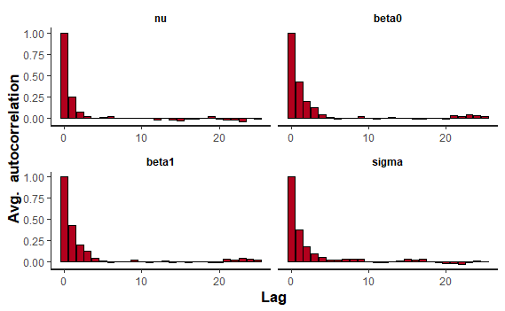

```r
plot(fit_WtHt30_robust, plotfun = "ac",
     pars = c("nu", "beta0", "beta1", "sigma"))
```

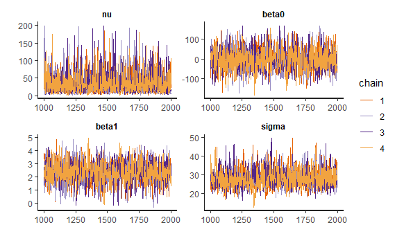

```r
plot(fit_WtHt30_robust, plotfun = "trace",
     pars = c("nu", "beta0", "beta1", "sigma"))
```

## Summarizing the model

```r
print(fit_WtHt30_robust, pars = c("nu", "beta0", "beta1", "sigma"))
```

```
Inference for Stan model: stan-14e450f15521.
4 chains, each with iter=2000; warmup=1000; thin=1;
post-warmup draws per chain=1000, total post-warmup draws=4000.

       mean se_mean    sd    2.5%    25%   50%   75%  97.5% n_eff
nu    34.50    0.61 28.20    4.38  14.32 26.74 46.77 109.43  2139
beta0 -1.65    1.37 53.02 -102.22 -37.91 -0.40 32.76 106.74  1509
beta1  2.32    0.02  0.79    0.72   1.81  2.31  2.86   3.82  1522
sigma 28.01    0.12  4.67   20.37  24.76 27.56 30.74  38.54  1462
      Rhat
nu       1
beta0    1
beta1    1
sigma    1

Samples were drawn using NUTS(diag_e) at Fri May 31 07:43:51 2019.
For each parameter, n_eff is a crude measure of effective sample size,
and Rhat is the potential scale reduction factor on split chains (at
convergence, Rhat=1).
```

## Visualizing the model

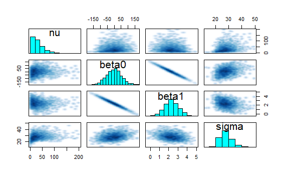

```r
pairs(fit_WtHt30_robust, pars = c("nu", "beta0", "beta1", "sigma"))
```

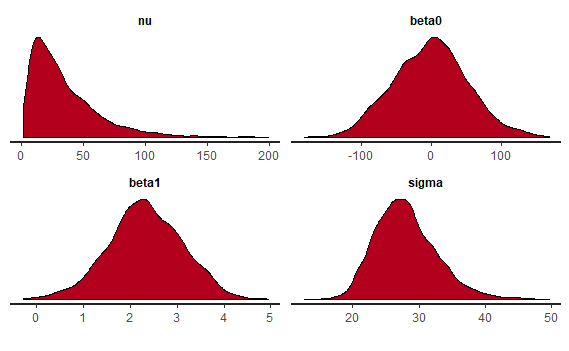

```r
plot(fit_WtHt30_robust, plotfun = "dens",
     pars = c("nu", "beta0", "beta1", "sigma"))
```

```
ci_level: 0.8 (80% intervals)
outer_level: 0.95 (95% intervals)
```

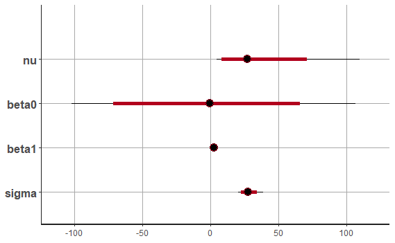

```r
plot(fit_WtHt30_robust, pars = c("nu", "beta0", "beta1", "sigma"))
```

The huge range on the intercept is due to the fact that small changes to the slope way out to the right of the graph will result in lines that meet the y-axis in wildly different places. This is a good reason to standardize (or at least mean-center the data).

## The mean-centered model

```r
set.seed(11111)
fit_WtHt30_robust_mc <- sampling(WtHt_robust, data = stan_data_30_mc, refresh = 0)
```

Much better diagnostic plots:

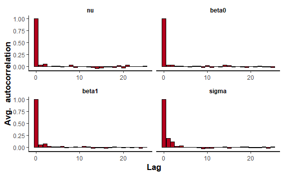

```r
plot(fit_WtHt30_robust_mc, plotfun = "ac",
     pars = c("nu", "beta0", "beta1", "sigma"))
```

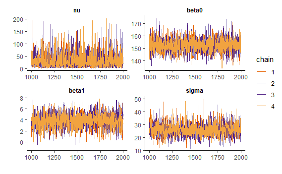

```r
plot(fit_WtHt30_robust_mc, plotfun = "trace",
     pars = c("nu", "beta0", "beta1", "sigma"))
```

Reasonable values for the parameters and their standard deviations:

```r
print(fit_WtHt30_robust_mc, pars = c("nu", "beta0", "beta1", "sigma"))
```

```
Inference for Stan model: stan-14e450f15521.
4 chains, each with iter=2000; warmup=1000; thin=1;
post-warmup draws per chain=1000, total post-warmup draws=4000.

        mean se_mean    sd   2.5%    25%    50%    75%  97.5% n_eff
nu     28.08    0.48 26.72   2.75   9.26  19.44  38.17 101.06  3122
beta0 152.30    0.09  5.16 142.47 148.83 152.22 155.64 162.54  3288
beta1   3.84    0.02  1.20   1.39   3.05   3.86   4.68   6.11  2828
sigma  25.98    0.10  4.61  17.72  22.90  25.75  28.80  35.59  2234
      Rhat
nu       1
beta0    1
beta1    1
sigma    1

Samples were drawn using NUTS(diag_e) at Fri May 31 07:44:44 2019.
For each parameter, n_eff is a crude measure of effective sample size,
and Rhat is the potential scale reduction factor on split chains (at
convergence, Rhat=1).
```

The beta parameters are now uncorrelated:

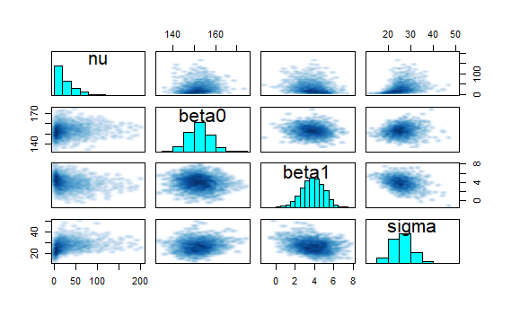

```r
pairs(fit_WtHt30_robust_mc, pars = c("nu", "beta0", "beta1", "sigma"))
```

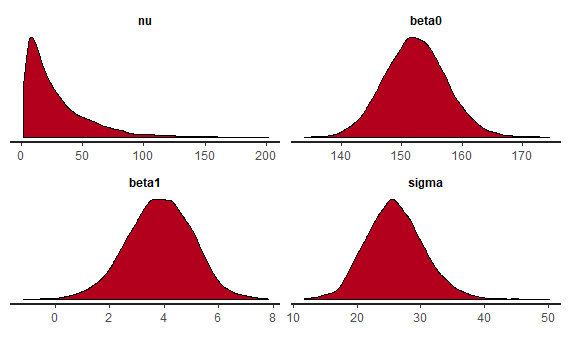

```r
plot(fit_WtHt30_robust_mc, plotfun = "dens",
     pars = c("nu", "beta0", "beta1", "sigma"))
```

Tight estimates of the parameters:

```
ci_level: 0.8 (80% intervals)
outer_level: 0.95 (95% intervals)
```

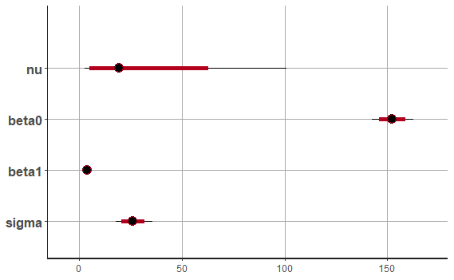

```r
plot(fit_WtHt30_robust_mc, pars = c("nu", "beta0", "beta1", "sigma"))
```

## Examining the prior

```stan
data {
    int<lower = 0> N;
    vector[N] x;
    vector<lower = 0>[N] y;
}
transformed data {
    real<lower = 0> Rate;
    real<lower = 0> M0;
    real<lower = 0> S0;
    real<lower = 0> M1;
    real<lower = 0> S1;
    real<lower = 0> L;
    real<lower = 0> H;

    Rate = 1.0/29.0;
    M0 = 70;
    S0 = 70;
    M1 = 0;
    S1 = 3;
    L = 0;
    H = 1000;
}
parameters {
    real<lower = 0> nu_minus_one;
    real beta0;
    real beta1;
    real<lower = 0> sigma;
}
transformed parameters {
    real<lower = 1> nu;
    vector<lower = 0>[N] mu;

    nu = nu_minus_one + 1;
    mu = beta0 + beta1 * x;
}
model {
    nu_minus_one ~ exponential(Rate);
    beta0 ~ normal(M0, S0);
    beta1 ~ normal(M1, S1);
    sigma ~ uniform(L, H);
//    y ~ student_t(nu, mu, sigma);
}
```

```r
set.seed(11111)
fit_WtHt30_robust_prior <- sampling(WtHt_robust_prior,
                             data = stan_data_30_mc,
                             refresh = 0)
```

```
There were 3618 divergent transitions after warmup. Increasing adapt_delta above 0.8 may help. See
http://mc-stan.org/misc/warnings.html#divergent-transitions-after-warmupExamine the pairs() plot to diagnose sampling problems
```

```r
print(fit_WtHt30_robust_prior,
      pars = c("nu", "beta0", "beta1", "sigma"))
```

```
Inference for Stan model: stan-14e41e764f37.
4 chains, each with iter=2000; warmup=1000; thin=1;
post-warmup draws per chain=1000, total post-warmup draws=4000.

        mean se_mean     sd  2.5%    25%    50%    75%  97.5% n_eff
nu     30.57    1.49  29.05  1.75   9.82  21.19  43.62 111.33   382
beta0  97.35    3.08  52.31 17.16  57.60  90.29 129.72 214.17   288
beta1  -0.14    0.15   2.74 -5.38  -2.01  -0.20   1.66   5.37   342
sigma 481.64   16.48 286.98 23.27 233.06 466.24 730.46 969.39   303
      Rhat
nu    1.01
beta0 1.01
beta1 1.01
sigma 1.02

Samples were drawn using NUTS(diag_e) at Fri May 31 07:46:17 2019.
For each parameter, n_eff is a crude measure of effective sample size,
and Rhat is the potential scale reduction factor on split chains (at
convergence, Rhat=1).
```

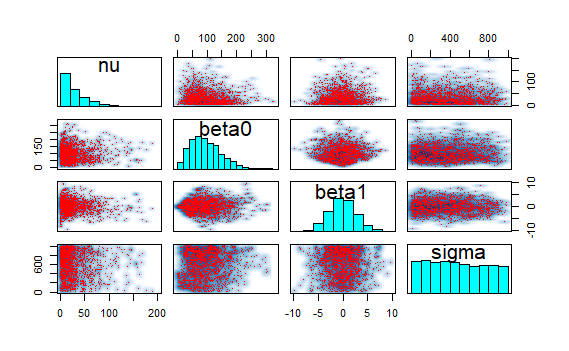

```r
pairs(fit_WtHt30_robust_prior,
      pars = c("nu", "beta0", "beta1", "sigma"))
```

```
ci_level: 0.8 (80% intervals)
outer_level: 0.95 (95% intervals)
```

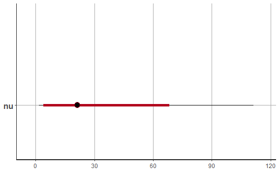

```r
plot(fit_WtHt30_robust_prior, pars = c("nu"))
```

```
ci_level: 0.8 (80% intervals)
outer_level: 0.95 (95% intervals)
```

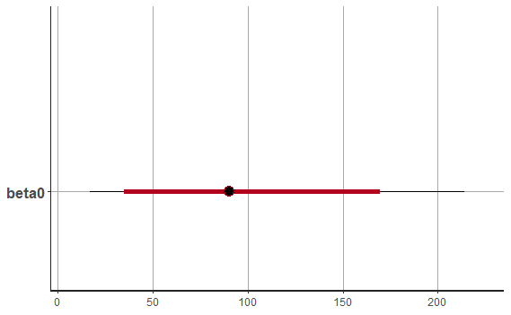

```r
plot(fit_WtHt30_robust_prior, pars = c("beta0"))
```

```
ci_level: 0.8 (80% intervals)
outer_level: 0.95 (95% intervals)
```

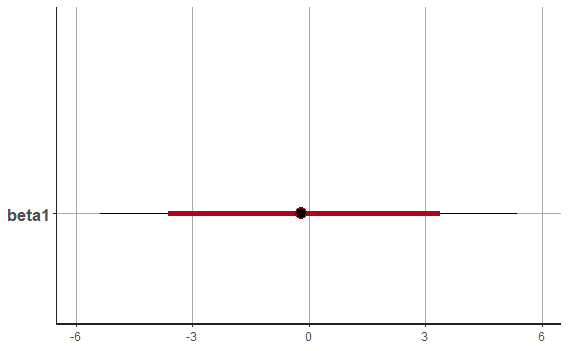

```r
plot(fit_WtHt30_robust_prior, pars = c("beta1"))
```

```
ci_level: 0.8 (80% intervals)
outer_level: 0.95 (95% intervals)
```

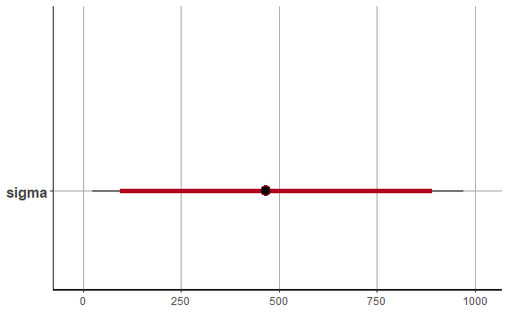

```r
plot(fit_WtHt30_robust_prior, pars = c("sigma"))
```

## The model with 300 observations

```r
set.seed(11111)
fit_WtHt300_robust_mc <- sampling(WtHt_robust,
                           data = stan_data_300_mc,
                           refresh = 0)
```

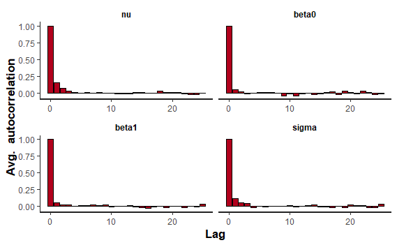

```r
plot(fit_WtHt300_robust_mc, plotfun = "ac",
     pars = c("nu", "beta0", "beta1", "sigma"))
```

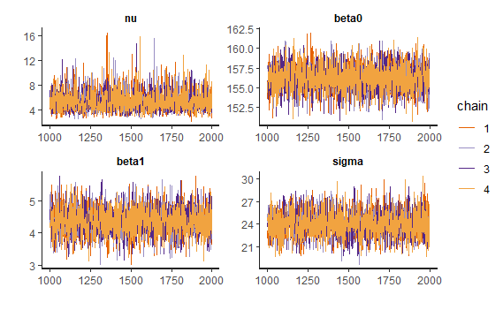

```r
plot(fit_WtHt300_robust_mc, plotfun = "trace",
     pars = c("nu", "beta0", "beta1", "sigma"))
```

```r
print(fit_WtHt300_robust_mc, pars = c("nu", "beta0", "beta1", "sigma"))
```

```
Inference for Stan model: stan-14e450f15521.
4 chains, each with iter=2000; warmup=1000; thin=1;
post-warmup draws per chain=1000, total post-warmup draws=4000.

        mean se_mean   sd   2.5%    25%    50%    75%  97.5% n_eff
nu      5.37    0.03 1.57   3.19   4.26   5.07   6.13   9.13  2655
beta0 156.21    0.03 1.63 152.99 155.12 156.21 157.29 159.41  3593
beta1   4.38    0.01 0.41   3.60   4.11   4.37   4.65   5.19  3370
sigma  23.98    0.03 1.58  20.92  22.96  23.92  25.01  27.24  2887
      Rhat
nu       1
beta0    1
beta1    1
sigma    1

Samples were drawn using NUTS(diag_e) at Fri May 31 07:46:38 2019.
For each parameter, n_eff is a crude measure of effective sample size,
and Rhat is the potential scale reduction factor on split chains (at
convergence, Rhat=1).
```

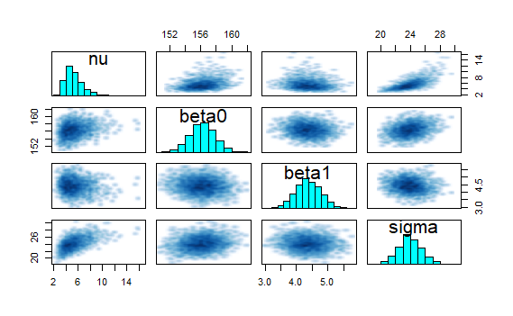

```r
pairs(fit_WtHt300_robust_mc, pars = c("nu", "beta0", "beta1", "sigma"))
```

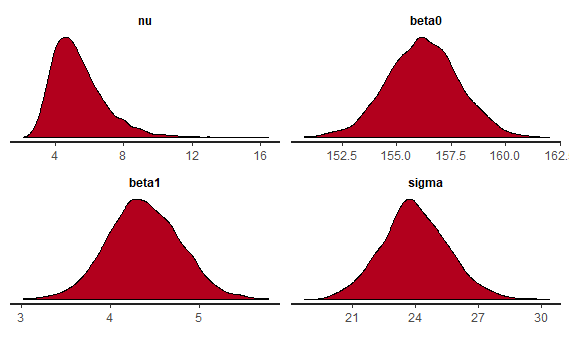

```r
plot(fit_WtHt300_robust_mc, plotfun = "dens",
     pars = c("nu", "beta0", "beta1", "sigma"))
```

```
ci_level: 0.8 (80% intervals)
outer_level: 0.95 (95% intervals)
```

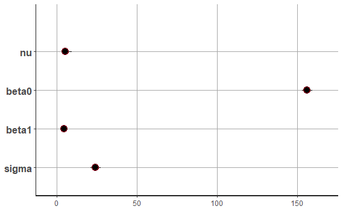

```r
plot(fit_WtHt300_robust_mc, pars = c("nu", "beta0", "beta1", "sigma"))
```

## Posterior predictive check

We’ll just do this for the example with 30 observations.

```r
y <- y30
```

Extract predicted values:

```r
samples_WtHt30 <- extract(fit_WtHt30_robust)
y_rep <- samples_WtHt30$y_rep
```

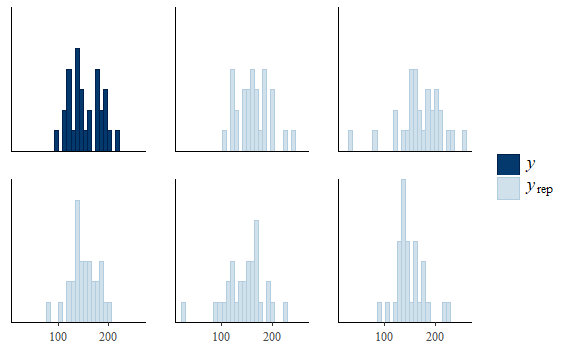

```r
ppc_hist(y, y_rep[1:5, ])
```

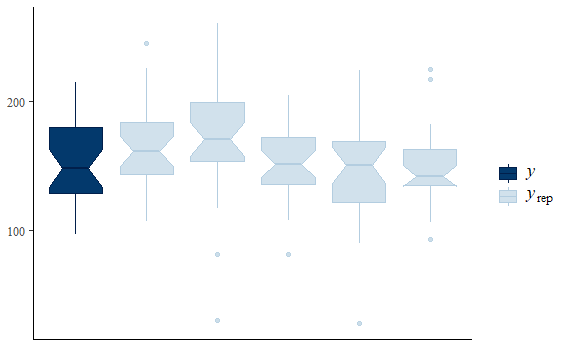

```r
ppc_boxplot(y, y_rep[1:5, ])
```

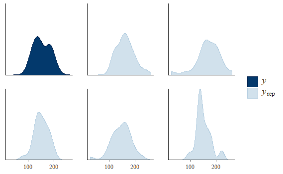

```r
ppc_dens(y, y_rep[1:5, ])
```

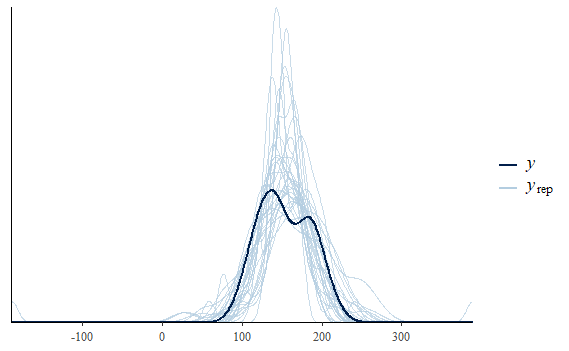

```r
ppc_dens_overlay(y, y_rep[1:30, ])
```

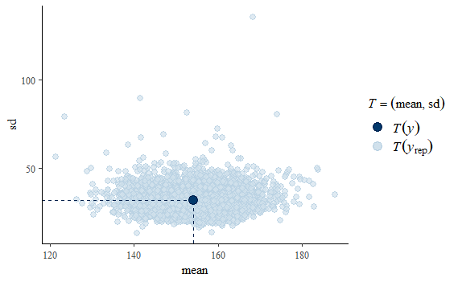

```r
ppc_stat_2d(y, y_rep)
```

## ShinyStan

Run the following code from the Console:

```
launch_shinystan(fit_WtHt30_robust)
```